# What personal trait is related with wealth accumulation?

Zhixing Zhou

2022-12-20

```r
knitr::opts_chunk$set(echo = TRUE)
knitr::opts_chunk$set(tidy.opts=list(width.cutoff=60),tidy=TRUE)
```

# What Personal Trait Is Related With Wealth Accumulation?

## 1. Introduction & literature review

### *The personal traits’ relationship with wealth accumulation*

Understanding wealth accumulation’s influence factor is important. The wealth management corporations can use these knowledge to advise individuals to learn, train and make better finance decisions. The current financial planning and advising focus mainly about individual’s risk-appetite, while other actions may be as well important for financial activities. (Fenton-O’Creevy & Furnham, 2022) Consequently, beside some social-economic factors, it’s helpful for these advisors to understand the individual traits of people who accumulates more wealth. I will focus on two factors, financial capabilities and financial knowledge, as well as other demographical factors in its relation to personal wealth accumulation in this analysis.

### *Factors influencing wealth accumulation*

Past studies show that there’re may be many factors influencing wealth accumulation. Social/demographical factors includes income(positive); age(positive); gender(being female is negative); education(positive) (Fenton-O’Creevy & Furnham, 2022)

Personal traits also influence wealth accumulation. In a study that uses this dataset, the author analyze the dataset and find that financial capabilities of planning ahead shows the strongest positive associations, and the money attitude of seeing money as security has the strongest positive association.(Fenton-O’Creevy & Furnham, 2022)What’s more, personalities of extroversion and conscientiousness is positively associated with wealth, while agreeableness is negatively associated with wealth, based on big 5 factors of personality traits.(Nabeshima & Seay, 2015)

### *The dataset and relevant findings*

The dataset is gathered by an social survey conducted by BBC called “Big Money Test” on 2011, the data is restored at UK Data Service. (Fenton-O’Creevy,M., Furnham, A. ,2017) There’re Three essays that used this dataset. They focus on following causal relationships.

One study find that the impulsive buying behavior is related with those who have not enough emotion regulation strategies.(Fenton‐O’Creevy et al., 2018) Other research shows that adverse financial outcomes is associated with financial capabilities, money attitudes and socio-economic status;(Von Stumm et al., 2013)and that there’re difference by sex in money pathology( money sanity) that female exhibit more money pathology(pathological money attitudes) than males. Female score more in regarding money as love, and male score more in regarding money as power, security and freedom. (Furnham et al., 2015)

## 2. Methods and Sample

### *Method intended to be used in the essay*

This analysis is intended to use several demographical variables and variables describing a person’s financial knowledge and financial capabilities to predict a individual’s potential in wealth accumulation.

This analysis will be about exploratory analysis of the data. The statistical methods will include descriptive data analysis, correlation analysis, simple linear regression. Further data analysis may include multivariate regression.

The graphical methods will include visualization of descriptive data analysis including scatter plot, bar plot, histogram and boxplot. Visualization of correlation includes plotting of correlation coefficients. There’re also diagnostic plots for regression.

### *The sample and data cleaning and wrangling process*

The survey data is processed according to notes of the survey to transform answers of questions to variables. The original data contains various dimensions of personal traits including Demographic variables, Money sanity, emotion regulation, vigilant and avoidant responses to threat, financial knowledge, behavioral inhibition, impulsive buying, adverse financial life events, financial capabilities, etc.

My analysis chose some of these variables. Including the demographic variables( Age, Education, Annual Household Income, Political Orientation, Religiousness, Ethnicity, Gender ), the personal trait variables (Financial Knowledge, Financial Capabilities (including Making Ends Meet, Keeping Track, Planning Ahead, Choosing Products, Staying Informed)), and the dependent variables( Level of Minimum Saving transformed into Minimum Value of Savings). The answer to the questions were processed to attain these variables. There’re 109472 observations in total. I filtered those with dependent variable ( Minimum value of Savings ) being NA. After that there’re 99636 observations. I then filled NAs in other variables by using the variables’ mean.

The descriptive analysis of the variables are as follows.

Cleaning Data

```r
library(tidyverse)
```

```r
library(haven)  # read and write statistical software dataset files
library(corrplot)  #correlation coefficient plotting
library(car)  # recoding data
# Disable scientific notation
options(scipen = 100)

# Set system language as English
Sys.setenv(LANGUAGE = "en")

# Read Data
setwd("D:/文件整理/TC - Fall Courses/HUDM 5026 Intro to Data Analysis in R/Final")
bbc <- read_dta("bbc_big_money_test_deposited_version.dta")
bbc <- as.data.frame(bbc)
bbc0 <- bbc %>%
    mutate(across(.cols = where(is.integer), .fns = as.numeric))

# Selecting Variables
bbctry <- bbc0[, c("q159", "wealth2", "Age", "q3", "q6", "PoliticOrient",
    "Religiousness", "FinancialKnowledge", "FCMakingEndsMeet",
    "FCKeepingTrack", "FCPlanningAhead", "FCChoosingProducts",
    "FCStayingInformed", "Ethnicity", "female")]
# datasets includes three parts, dependent variable,
# independent variable, dummy variable Personal wealth: the
# average level of three personal wealth variables, which
# can only be used after levels of NA has been filtered.
# wealth 1/2/3: the minimum value of the person's level of
# certain wealth. Wealth less than 0 are regarded same as
# 0~500.  We should choose wealth2, it is savings and
# financial investments Financial Capabilities: the sum of
# all related questions' level.

# Recoding data
bbctry$q6 <- car::recode(bbctry$q6, "1=0;2=10000;3=20000;4=30000;5=40000;6=50000;7=75000;8=150000;else=NA")
# recode q6: the minimum of gross annual household income
bbctryt <- bbctry %>%
    mutate(FinancialCapabilities = FCMakingEndsMeet + FCKeepingTrack +
        FCPlanningAhead + FCStayingInformed + FCChoosingProducts)  #Calculate FinancialCapabilities: add up five variables of financial capabilities
bbctryt <- as.data.frame(bbctryt[, c(1:13, 16, 14:15)])
bbctry <- bbctryt
# ethnicity and female: categorial variables

# Rename Variables
bbctry <- bbctry %>%
    rename(SavingLevel = "q159", MinSavings = "wealth2", Income = "q6",
        Education = "q3", Gender = "female")

# Check for null value
sum(is.na(bbctry$wealth2))
```

```
## [1] 0
```

```r
# Filter and Filling NAs for analysis
na <- colSums(is.na(bbctry))
bbctry1 <- bbctry %>%
    filter(!is.na(MinSavings))  # filter: wealth2  level of not NA;
funm <- function(x) {
    x[is.na(x)] <- mean(x, na.rm = TRUE)
    x
}
bbctry2 <- as.data.frame(mapply(funm, bbctry1))  # use mean to fill the NAs in Income and Age
na2 <- colSums(is.na(bbctry2))
bbctried <- bbctry2 %>%
    mutate(across(.cols = 1:ncol(bbctry2), .fns = as.numeric))  #mutate, turn every variable as numeric
```

Descriptive Statistics

```r
# Do summary statistics for variables
Mean <- mapply(mean, bbctry, na.rm = TRUE)
Std.Deviation <- mapply(sd, bbctry, na.rm = TRUE)
stat <- data.frame(Mean, Std.Deviation)
stat <- stat %>%
    mutate(Var = Std.Deviation^2)
n <- mapply(function(x) {
    sum(!is.na(x))
}, bbctry)
stat <- cbind(stat, n)

Mean <- mapply(mean, bbctried, na.rm = TRUE)
Std.Deviation <- mapply(sd, bbctried, na.rm = TRUE)
stat3 <- data.frame(Mean, Std.Deviation)
stat3 <- stat3 %>%
    mutate(Var = Std.Deviation^2)
n <- mapply(function(x) {
    sum(!is.na(x))
}, bbctried)
stat3 <- cbind(stat3, n)
```

Descriptive Statistics Before Filling and filtering NAs

```r
stat
```

```
##                                Mean Std.Deviation               Var      n
## SavingLevel               5.0779688     2.7734688         7.6921292 109454
## MinSavings            13073.2817456 18133.4020752 328820270.8218482  99636
## Age                      39.5820459    13.7031804       187.7771544 109390
## Education                 4.1514177     1.4853749         2.2063387 109472
## Income                33539.7274263 26033.4972586 677742979.5158561 101844
## PoliticOrient             5.2815971     1.7472137         3.0527556 109472
## Religiousness             3.3972888     2.5763725         6.6376951 109472
## FinancialKnowledge        6.1415613     1.4589323         2.1284836 109472
## FCMakingEndsMeet         16.8708346     3.4535026        11.9266801 109472
## FCKeepingTrack           14.7611170     3.0597243         9.3619129 109472
## FCPlanningAhead          15.2770297     4.0540775        16.4355447 109472
## FCChoosingProducts       16.8728807     3.0154802         9.0931206 109472
## FCStayingInformed        15.5824868     3.6462788        13.2953489 109472
## FinancialCapabilities    79.3643489    11.6289355       135.2321398 109472
## Ethnicity                 1.2717316     0.8453284         0.7145801 109472
## Gender                    0.5325745     0.4989400         0.2489412 109472
```

Descriptive Statistics After Filling and filtering NAs

```r
stat3
```

```
##                                Mean Std.Deviation               Var     n
## SavingLevel               4.6250853     2.4782814         6.1418785 99636
## MinSavings            13073.2817456 18133.4020752 328820270.8218482 99636
## Age                      39.5764429    13.5114102       182.5582065 99636
## Education                 4.1886366     1.4683888         2.1561657 99636
## Income                34111.5920052 25492.6024612 649872780.2430937 99636
## PoliticOrient             5.2911197     1.7526694         3.0718501 99636
## Religiousness             3.3631820     2.5645007         6.5766638 99636
## FinancialKnowledge        6.1855655     1.4452490         2.0887447 99636
## FCMakingEndsMeet         16.8924786     3.4378233        11.8186292 99636
## FCKeepingTrack           14.7681762     3.0522710         9.3163580 99636
## FCPlanningAhead          15.3449255     4.0226026        16.1813313 99636
## FCChoosingProducts       16.9198884     2.9590920         8.7562257 99636
## FCStayingInformed        15.6507186     3.5944673        12.9201953 99636
## FinancialCapabilities    79.5761873    11.4557957       131.2352553 99636
## Ethnicity                 1.2526095     0.8179319         0.6690126 99636
## Gender                    0.5246497     0.4993945         0.2493949 99636
```

## 3. Findings

Correlation

```r
# Correlation Between variables
cormatrix <- bbctried %>%
    cor() %>%
    as.data.frame()
cormatrix
```

```
##                        SavingLevel    MinSavings         Age     Education
## SavingLevel            1.000000000  0.8236555049  0.40884915  0.1358997977
## MinSavings             0.823655505  1.0000000000  0.45356433  0.0965984160
## Age                    0.408849145  0.4535643278  1.00000000 -0.1463728880
## Education              0.135899798  0.0965984160 -0.14637289  1.0000000000
## Income                 0.292229639  0.2822226882  0.02915834  0.2624275072
## PoliticOrient         -0.090433113 -0.1014083169 -0.05992064  0.1241647469
## Religiousness          0.019780414  0.0005212714  0.06251723  0.0432469527
## FinancialKnowledge     0.198169034  0.1827561842  0.11937662  0.1736973890
## FCMakingEndsMeet       0.611216889  0.4231120498  0.23252789  0.1174396417
## FCKeepingTrack        -0.058855110 -0.0322138907  0.06594841 -0.1333849506
## FCPlanningAhead        0.770796023  0.5707905715  0.33779916  0.1590215502
## FCChoosingProducts     0.284776382  0.2310599429  0.18582725  0.1422760689
## FCStayingInformed      0.290767924  0.2607395680  0.20849963  0.1105929595
## FinancialCapabilities  0.603192959  0.4603146032  0.31938759  0.1269943198
## Ethnicity              0.002808522 -0.0135574941 -0.09450796  0.0880803207
## Gender                -0.156502744 -0.1639040955 -0.03945637 -0.0009141658
##                             Income PoliticOrient Religiousness
## SavingLevel            0.292229639   -0.09043311  0.0197804135
## MinSavings             0.282222688   -0.10140832  0.0005212714
## Age                    0.029158338   -0.05992064  0.0625172291
## Education              0.262427507    0.12416475  0.0432469527
## Income                 1.000000000   -0.08194191 -0.0168241613
## PoliticOrient         -0.081941913    1.00000000 -0.0588512634
## Religiousness         -0.016824161   -0.05885126  1.0000000000
## FinancialKnowledge     0.157567166    0.00636536 -0.0295949696
## FCMakingEndsMeet       0.204917849   -0.07419032 -0.0135827269
## FCKeepingTrack        -0.127598058   -0.05238877  0.0085239058
## FCPlanningAhead        0.297791965   -0.08839261  0.0222687548
## FCChoosingProducts     0.142580103   -0.03985246  0.0131134188
## FCStayingInformed      0.176874492   -0.09031780  0.0344630089
## FinancialCapabilities  0.224391524   -0.10589380  0.0202151455
## Ethnicity              0.006626025    0.03385634  0.1541968439
## Gender                -0.137107526    0.10674506  0.1103430294
##                       FinancialKnowledge FCMakingEndsMeet FCKeepingTrack
## SavingLevel                   0.19816903       0.61121689   -0.058855110
## MinSavings                    0.18275618       0.42311205   -0.032213891
## Age                           0.11937662       0.23252789    0.065948413
## Education                     0.17369739       0.11743964   -0.133384951
## Income                        0.15756717       0.20491785   -0.127598058
```

[output cut: 30 more lines]

```
## MinSavings                       0.46031460 -0.013557494 -0.1639040955
## Age                              0.31938759 -0.094507962 -0.0394563728
## Education                        0.12699432  0.088080321 -0.0009141658
## Income                           0.22439152  0.006626025 -0.1371075265
## PoliticOrient                   -0.10589380  0.033856343  0.1067450606
## Religiousness                    0.02021515  0.154196844  0.1103430294
## FinancialKnowledge               0.24800723 -0.052186229 -0.0731211043
## FCMakingEndsMeet                 0.75370309 -0.030634873 -0.1240902468
## FCKeepingTrack                   0.40016910 -0.045533712  0.0323782340
## FCPlanningAhead                  0.77289604 -0.028687738 -0.1169984862
## FCChoosingProducts               0.67835367 -0.034408731 -0.0366638853
## FCStayingInformed                0.70299945  0.000682973 -0.1450801639
## FinancialCapabilities            1.00000000 -0.040072428 -0.1246870463
## Ethnicity                       -0.04007243  1.000000000 -0.0441277164
## Gender                          -0.12468705 -0.044127716  1.0000000000
```

Visualization of Correlation

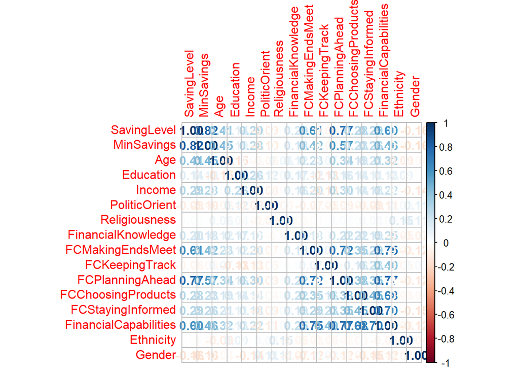

```r
# Plotting Correlations
corrplot(cor(bbctried), method = "number")
```

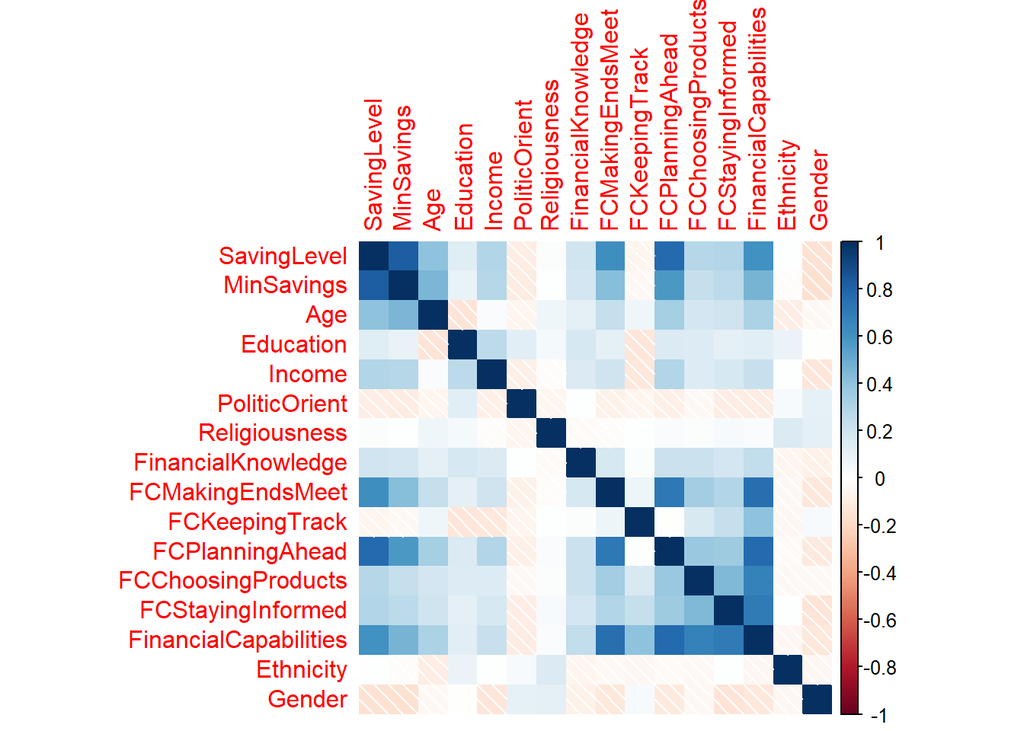

```r
corrplot(cor(bbctried), method = "shade")
```

Visualization of Variables and its Relations

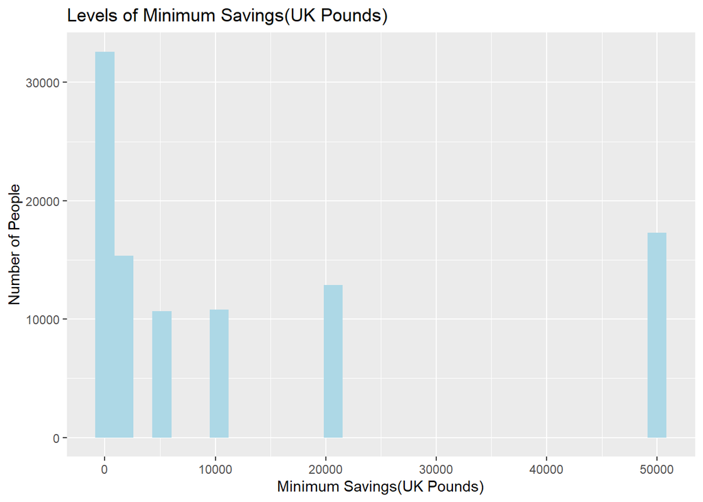

```r
# build a histogram of MinSavings to show distribution of
# wealth in the sample
ggplot(data = bbctried) + geom_histogram(aes(x = c(MinSavings)),
    fill = "lightblue") + xlab("Minimum Savings(UK Pounds)") +
    ylab("Number of People") + ggtitle("Levels of Minimum Savings(UK Pounds)")  # MinSavings
```

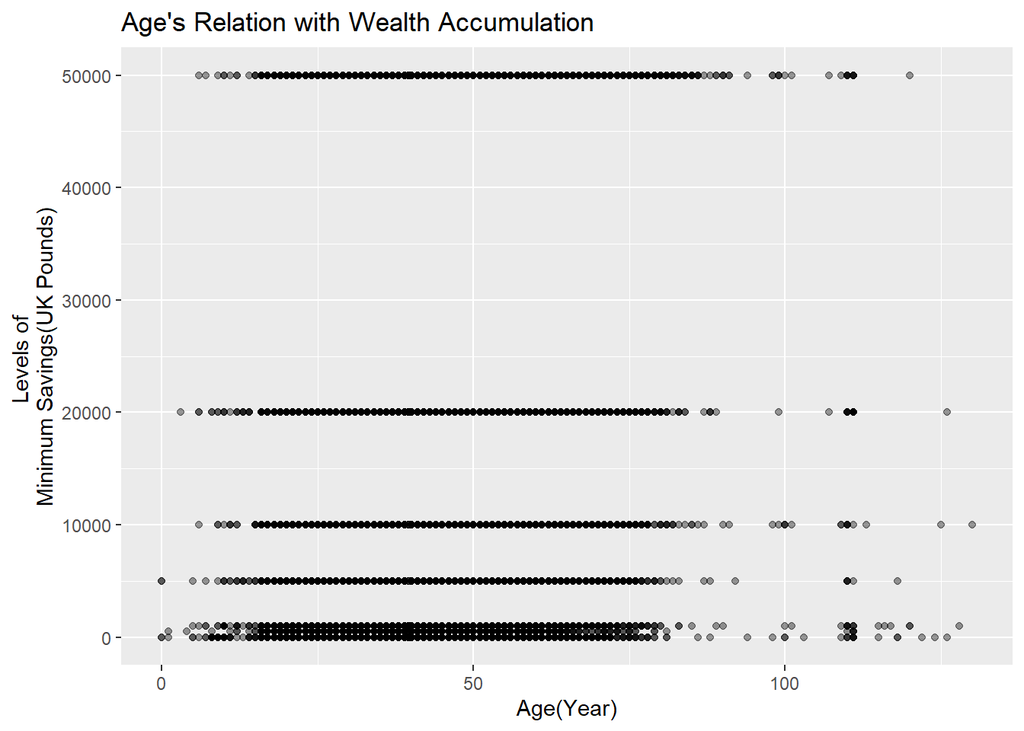

```r
# build a scatterplot of Minsavings and age to see their
# corrlelations
ggplot(data = bbctried, mapping = aes(x = Age, y = MinSavings)) +
    geom_point(alpha = 0.4) + ylab("Levels of \nMinimum Savings(UK Pounds)") +
    xlab("Age(Year)") + ggtitle("Age's Relation with Wealth Accumulation ")
```

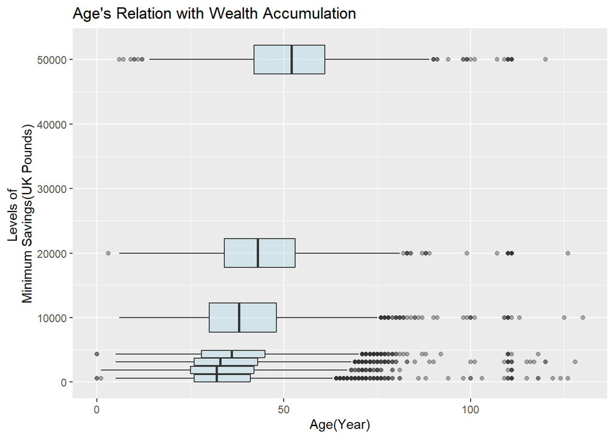

```r
# build a boxplot of Minsavings and age to show each groups
# in wealth and the average age and dispersion in age of
# that group of wealth. As well as their correlations.
ggplot(data = bbctried, mapping = aes(group = MinSavings, x = Age,
    y = MinSavings)) + geom_boxplot(width = 5000, alpha = 0.4,
    fill = "lightblue") + ylab("Levels of \nMinimum Savings(UK Pounds)") +
    xlab("Age(Year)") + ggtitle("Age's Relation with Wealth Accumulation ")  # wealth2 as age increases
```

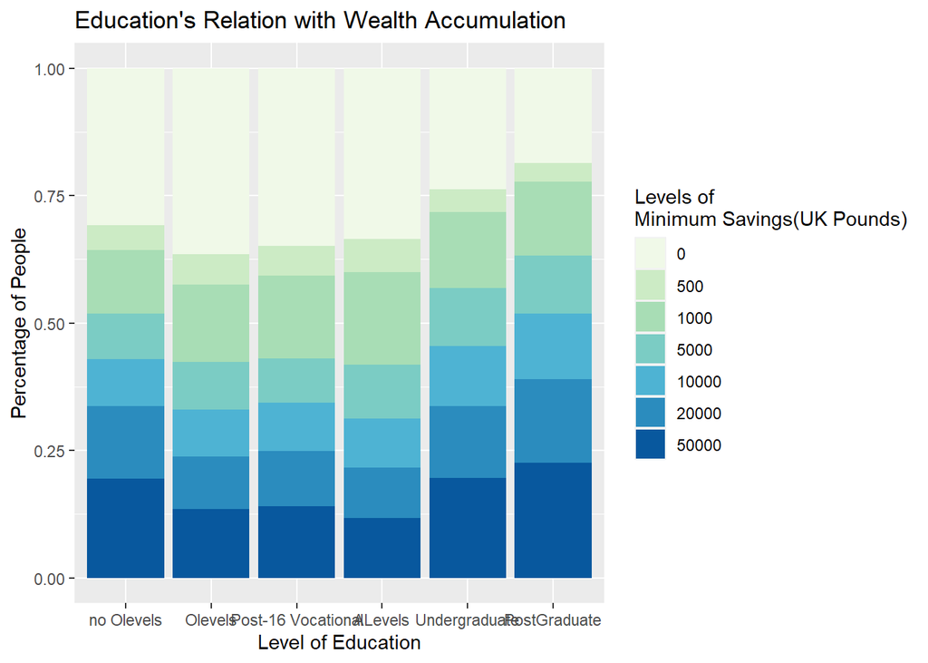

```r
# Draw a Barplot to show Education's Relation with Wealth
# Accumulation
ggplot(data = bbctried, mapping = aes(x = Education %>%
    as_factor(), group = MinSavings %>%
    as_factor(), fill = MinSavings %>%
    as_factor())) + geom_bar(stat = "count", position = "fill") +
    scale_fill_brewer(palette = "GnBu") + labs(fill = "Levels of \nMinimum Savings(UK Pounds)") +
    ylab("Percentage of People") + xlab("Level of Education") +
    scale_x_discrete(labels = c("no Olevels", "Olevels", "Post-16 Vocational",
        "ALevels", "Undergraduate", "PostGraduate")) + ggtitle("Education's Relation with Wealth Accumulation")
```

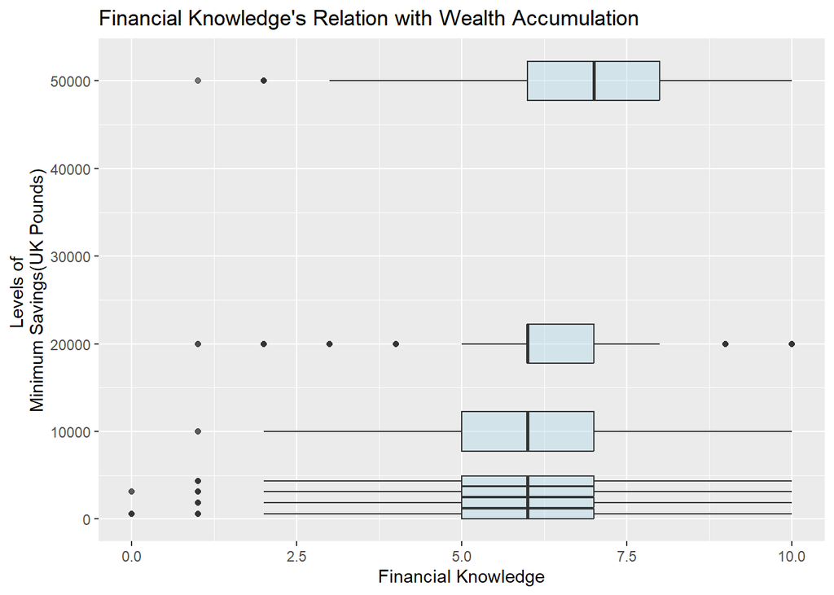

```r
# boxplot of Minsavings and Financial Knowledge
ggplot(data = bbctried, mapping = aes(group = MinSavings, x = FinancialKnowledge,
    y = MinSavings)) + geom_boxplot(width = 5000, alpha = 0.4,
    fill = "lightblue") + ylab("Levels of \nMinimum Savings(UK Pounds)") +
    xlab("Financial Knowledge") + ggtitle("Financial Knowledge's Relation with Wealth Accumulation ")
```

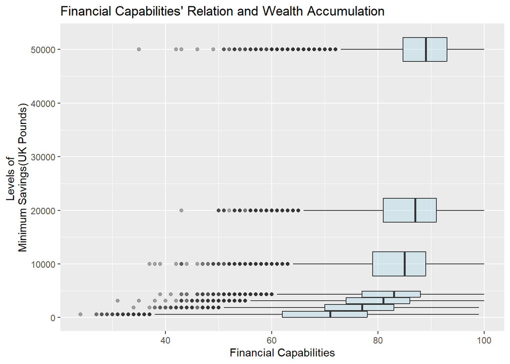

```r
# boxplot of Minsavings and Financial Capabilities
ggplot(data = bbctried, mapping = aes(group = MinSavings, x = FinancialCapabilities,
    y = MinSavings)) + geom_boxplot(width = 5000, alpha = 0.4,
    fill = "lightblue") + ylab("Levels of \nMinimum Savings(UK Pounds)") +
    xlab("Financial Capabilities") + ggtitle("Financial Capabilities' Relation and Wealth Accumulation ")
```

Regression Analysis

```r
# Conduct Regression Analysis

lm1 <- lm(data = bbctried, formula = MinSavings ~ FinancialKnowledge +
    log(FinancialCapabilities) + Age + Education + Income)
summary(lm1)
```

```
##
## Call:
## lm(formula = MinSavings ~ FinancialKnowledge + log(FinancialCapabilities) +
##     Age + Education + Income, data = bbctried)
##
## Residuals:
##    Min     1Q Median     3Q    Max
## -56246 -10120  -3219   6544  74249
##
## Coefficients:
##                                  Estimate     Std. Error t value
## (Intercept)                -148573.784439    1328.355987 -111.85
## FinancialKnowledge             419.925315      33.622536   12.49
## log(FinancialCapabilities)   30123.322982     322.760441   93.33
## Age                            500.816520       3.681800  136.03
## Education                      737.706499      33.761106   21.85
## Income                           0.136339       0.001926   70.77
##                                       Pr(>|t|)
## (Intercept)                <0.0000000000000002 ***
## FinancialKnowledge         <0.0000000000000002 ***
## log(FinancialCapabilities) <0.0000000000000002 ***
## Age                        <0.0000000000000002 ***
## Education                  <0.0000000000000002 ***
## Income                     <0.0000000000000002 ***
## ---
## Signif. codes:  0 '***' 0.001 '**' 0.01 '*' 0.05 '.' 0.1 ' ' 1
##
## Residual standard error: 14620 on 99630 degrees of freedom
## Multiple R-squared:  0.3497, Adjusted R-squared:  0.3497
## F-statistic: 1.072e+04 on 5 and 99630 DF,  p-value: < 0.00000000000000022
```

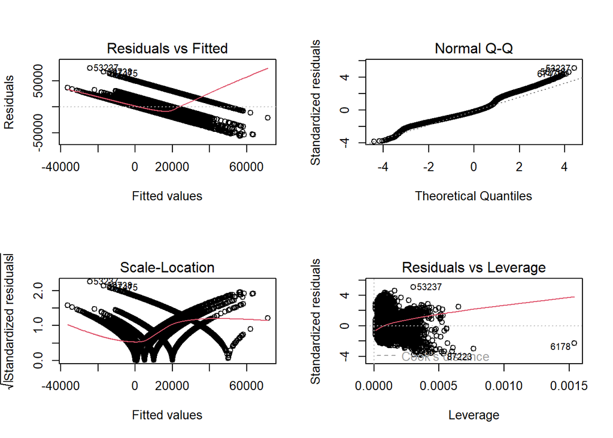

```r
par(mfrow = c(2, 2))
plot(lm1)
```

## 4. Discussion

### *Findings related to research questions*

I first describe levels of minimum savings in histogram and find that people with small amount of money and large amount of money seems to be not small in the sample while the middle class is smaller.

The analysis also made simple regression analysis for the data.

### *Weaknesses*

The analysis seems to touch the basics of variables but didn’t include more other personal traits into analysis, and it may compromise the final model’s explanation ability, with R-squared at 0.35. What’s more, detailed investigation about the regression model should be made.

The analysis visually described the variables well, but didn’t make very big contributions to existing academic literatures with exceptional conclusions.

## Citation

Fenton-O’Creevy, M., & Furnham, A. (2022). Money attitudes, financial capabilities, and impulsiveness as predictors of wealth accumulation. *Plos one*, *17*(11), e0278047.

Fenton‐O’Creevy, M., Dibb, S., & Furnham, A. (2018). Antecedents and consequences of chronic impulsive buying: Can impulsive buying be understood as dysfunctional self‐regulation? *Psychology & Marketing*, *35*(3), 175-188.

Furnham, A., Von Stumm, S., & Fenton-O’Creevy, M. (2015). Sex differences in money pathology in the general population. *Social indicators research*, *123*(3),701-711.

Nabeshima, G., & Seay, M. (2015). Wealth and personality: Can personality traits make your client rich. *Journal of Financial Planning*, *28*(7), 50-57.

Von Stumm, S., O’Creevy, M. F., & Furnham, A. (2013). Financial capability, money attitudes and socioeconomic status: Risks for experiencing adverse financial events. *Personality and Individual Differences*, *54*(3),344-349.

Fenton-O’Creevy, M., Furnham, A. (2017). BBC Big Money Test, 2011. [data collection]. *UK Data Service*. SN: 8132, DOI: 10.5255/UKDA-SN-8132-1